# Logistische Regression

Beispiel: Besteht ein Student / eine Studentin eine Klausur unter Berücksichtigung der Anzahl Stunden für die Vorbereitung auf die Klausur?

Wir laden zuerst den Datensatz.

```python
import pandas as pd
url = "https://raw.githubusercontent.com/troescherw/datasets/master/Klausur_Bestanden.csv"
df = pd.read_csv(url, delimiter=";")
df.head()
```

|  | Stunden | BesuchteVorlesungen | Vorbereitungskurs | KlausurBestanden |
| --- | --- | --- | --- | --- |
| 0 | 2 | 3 | 0 | 0 |
| 1 | 51 | 12 | 1 | 1 |
| 2 | 19 | 12 | 1 | 0 |
| 3 | 0 | 10 | 0 | 0 |
| 4 | 2 | 1 | 0 | 0 |

Wir erstellen einen Scatterplot.

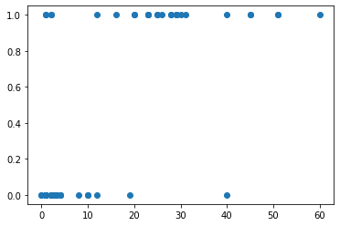

```python
%matplotlib inline
import matplotlib.pyplot as plt
plt.scatter(df.Stunden, df.KlausurBestanden)
plt.show()
```

Nun erstellen wir ein Vorhersagemodell mit Hilfe der Logistischen Regression. Wir verwenden wieder das Package *statsmodels.formula.api*. Als *family* geben wir *Binomial* an, da unsere abhängige Variable nur 2 Zustände annehmen kann (0 oder 1). *glm" steht für* Generalized Linear Model*.

```python
import statsmodels.formula.api as smf
import statsmodels.api as sm

model = smf.glm("KlausurBestanden~Stunden", data=df, family=sm.families.Binomial()).fit()
model.summary()
```

Generalized Linear Model Regression Results

| Dep. Variable: | KlausurBestanden | No. Observations: | 67 |
| --- | --- | --- | --- |
| Model: | GLM | Df Residuals: | 65 |
| Model Family: | Binomial | Df Model: | 1 |
| Link Function: | logit | Scale: | 1.0000 |
| Method: | IRLS | Log-Likelihood: | -23.982 |
| Date: | Mon, 12 Apr 2021 | Deviance: | 47.964 |
| Time: | 10:51:00 | Pearson chi2: | 115. |
| No. Iterations: | 6 |  |  |
| Covariance Type: | nonrobust |  |  |

|  | coef | std err | z | P>\|z\| | [0.025 | 0.975] |
| --- | --- | --- | --- | --- | --- | --- |
| Intercept | -2.3879 | 0.531 | -4.493 | 0.000 | -3.430 | -1.346 |
| Stunden | 0.1649 | 0.037 | 4.438 | 0.000 | 0.092 | 0.238 |

Die Koeffizienten lauten:

Für $\beta_0$: -2,39

Für $\beta_1$: 0,165

Wollen wir also zum Beispiel die Wahrscheinlichkeit berechnen, dass eine Studentin eine Klausur besteht, wenn Sie sich 30 Stunden auf die Klausur vorbereitet hat:

$P(Klausur Bestanden) = \frac{1}{1+e^{2,39-0,165\cdot 30}} = 0,93$

Oder wir berechnen diesen Wert mit Hilfe der *pred*-Funktion:

```python
model.predict({"Stunden":30})
```

```
0    0.928224
dtype: float64
```

Wir plotten noch die "Schwanenhalsfunktion" für die Vorhersagewahrscheinlichkeiten im Bereich der kleinsten und größten Stundenzahl aus dem Datensatz.

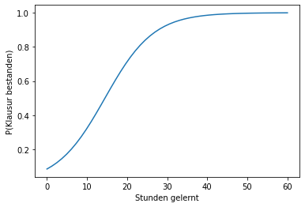

```python
%matplotlib inline
import matplotlib.pyplot as plt
import numpy as np

x = np.linspace(df.Stunden.min(), df.Stunden.max())
y = model.predict(pd.DataFrame({"Stunden":x}))

plt.plot(x,y)
plt.xlabel("Stunden gelernt")
plt.ylabel("P(Klausur bestanden)")
plt.show()
```